## Introduction

Lately I have been indulged in learning all things tidymodels in my after office hours. But I was missing something - the effectiveness of my learning journey. Committing to large scale competition was unwieldy but then came #Sliced - a data science problem solving 2-hour sprint with small datasets.

Here, I am trying to tackle the S0102 problem with **Aircraft wildlife strikes** dataset.

## Load Libraries and other presets

```r
library(tidyverse) # Data Wrangling
library(tidymodels) # Modelling
library(themis) # Class imbalance

library(parallel) # Parallel operations
library(doParallel) # Parallel operations
library(tictoc) # Timing

library(GGally) # For pair plots
```

### Enable parallel processing

```r
cores<-detectCores(logical=F)-1
# cores

core_cluster<-makePSOCKcluster(cores)
# core_cluster

registerDoParallel(core_cluster)
```

## Get Train and test data

Here I did a few things other than reading data - * Converted all character columns to factors to play nice with different models * Releveled factor so that our target outcome true label is “damaged”. It will make it easier to read the results.

### Train data

```r
train_orig<-read_csv("Data/S01E02/train.csv",
                     guess_max=1e5)%>%
  mutate(
    damaged=case_when(
      damaged>0 ~ "damaged",
      TRUE ~ "no damage"
    ),
    across(where(is.character),as_factor),
    damaged=fct_relevel(damaged,"damaged")
  )


# Check out training data
train_orig%>%
  glimpse()
```

```
## Rows: 21,000
## Columns: 34
## $ id               <dbl> 23637, 8075, 5623, 19605, 15142, 27235, 12726, 20781,~
## $ incident_year    <dbl> 1996, 1999, 2011, 2007, 2007, 2013, 2002, 2013, 2015,~
## $ incident_month   <dbl> 11, 6, 12, 9, 9, 5, 5, 5, 7, 8, 10, 9, 11, 7, 5, 3, 3~
## $ incident_day     <dbl> 7, 26, 1, 13, 13, 28, 4, 19, 22, 22, 21, 7, 2, 7, 20,~
## $ operator_id      <fct> MIL, UAL, SWA, SWA, MIL, UNK, UAL, BUS, UNK, BUS, EGF~
## $ operator         <fct> MILITARY, UNITED AIRLINES, SOUTHWEST AIRLINES, SOUTHW~
## $ aircraft         <fct> T-1A, B-757-200, B-737-300, B-737-700, KC-135R, UNKNO~
## $ aircraft_type    <fct> A, A, A, A, A, NA, A, A, NA, A, A, A, A, NA, A, A, A,~
## $ aircraft_make    <fct> 748, 148, 148, 148, NA, NA, 148, 226, NA, NA, 332, 58~
## $ aircraft_model   <dbl> NA, 26, 24, 42, NA, NA, 97, 7, NA, NA, 14, 22, 37, NA~
## $ aircraft_mass    <dbl> 3, 4, 4, 4, NA, NA, 4, 1, NA, 1, 3, 4, 4, NA, 4, 4, 4~
## $ engine_make      <dbl> 31, 34, 10, 10, NA, NA, 34, 7, NA, NA, 1, 34, 34, NA,~
## $ engine_model     <fct> 1, 40, 1, 1, NA, NA, 46, 10, NA, NA, 10, 10, 10, NA, ~
```

[output cut: 21 more lines]

### Test data

```r
test<-read_csv("Data/S01E02/test.csv",
               guess_max = 1e5
               )%>%
  mutate(
    across(where(is.character),as_factor)
  )
```

## Exploratory Data Analysis

Here I am not much focusing on EDA. But some charts will not hurt. Taken some queue from [Julia Silge’s post](https://juliasilge.com/blog/sliced-aircraft/) and added some of my own on top.

### Class balance check

> The outcome is severely imbalanced. We will address that in pre-processing step.

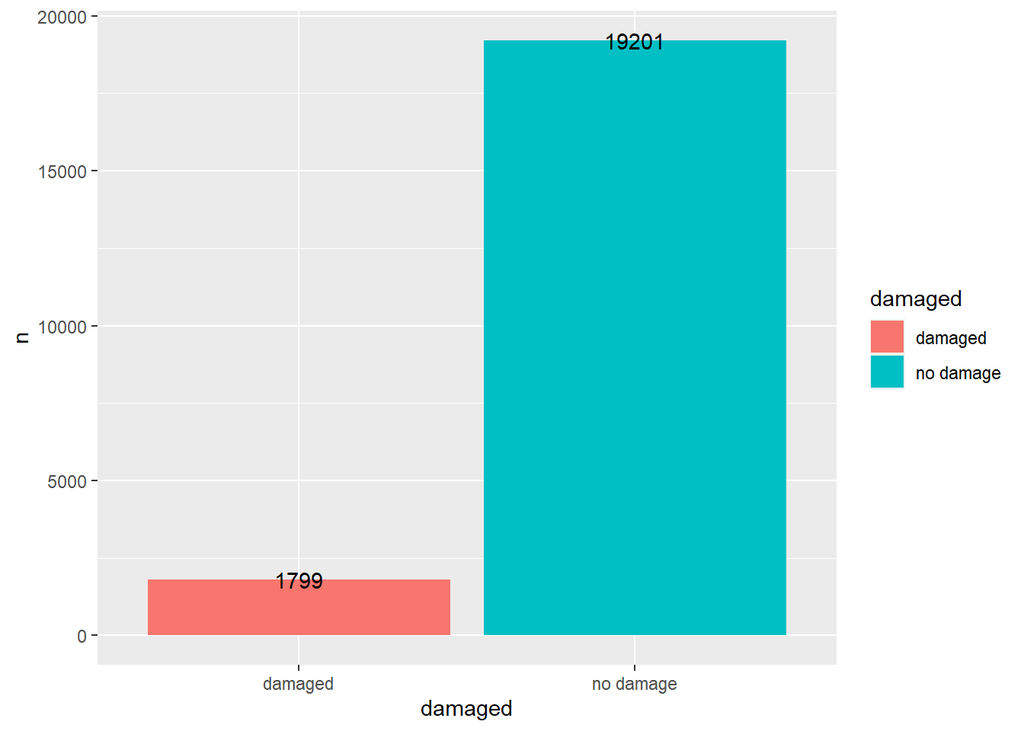

```r
train_orig%>%
  count(damaged)%>%
  ggplot(aes(damaged,n,fill=damaged))+
  geom_col()+
  geom_text(aes(label=n))
```

```r
balance_share<-train_orig%>%
  count(damaged)%>%
  mutate(
    share=n/sum(n)
  )%>%
  slice_max(share)%>%
  select(share)%>%
  pull()

balance_share # Will be using this on another viz
```

```
## [1] 0.9143333
```

### Checking Pair plots of numeric variables

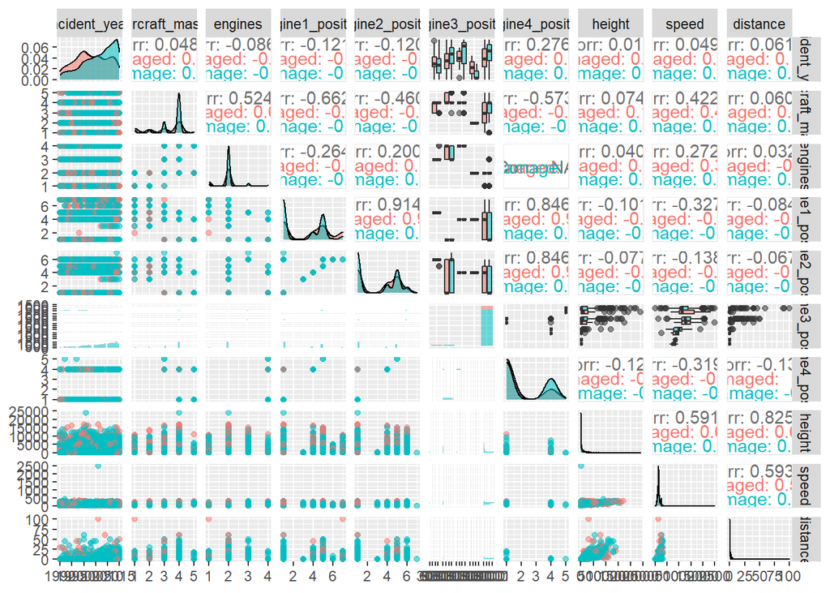

```r
train_orig%>%
  select(damaged,incident_year,aircraft_mass,
         engines,contains("_position"),
         height,speed,distance
         )%>%
  ggpairs(columns = 2:11,
          aes(color=damaged,alpha=0.5),
          progress=FALSE
          )
```

### Categorical variables exploration

So many categorical variables! Lets visualize those with less than 15 levels and see whether they are inline with the outcome imbalance.

```r
categoric_summary<-train_orig%>%
  select(where(is_character),where(is.factor))%>%
  map_df(~tibble(
          distinct=n_distinct(.x)
      ),
      .id="variable"
    )%>%
  arrange(-distinct)

categoric_summary
```

```
## # A tibble: 20 x 2
##    variable         distinct
##    <chr>               <int>
##  1 airport_id           1039
##  2 airport              1039
##  3 species_id            447
##  4 species_name          446
##  5 aircraft              424
##  6 operator_id           276
##  7 operator              275
##  8 aircraft_make          63
##  9 state                  61
## 10 engine_model           40
## 11 faa_region             15
## 12 flight_phase           13
## 13 engine_type             9
## 14 precipitation           9
## 15 flight_impact           7
## 16 visibility              6
## 17 engine3_position        5
## 18 species_quantity        5
## 19 aircraft_type           3
## 20 damaged                 2
```

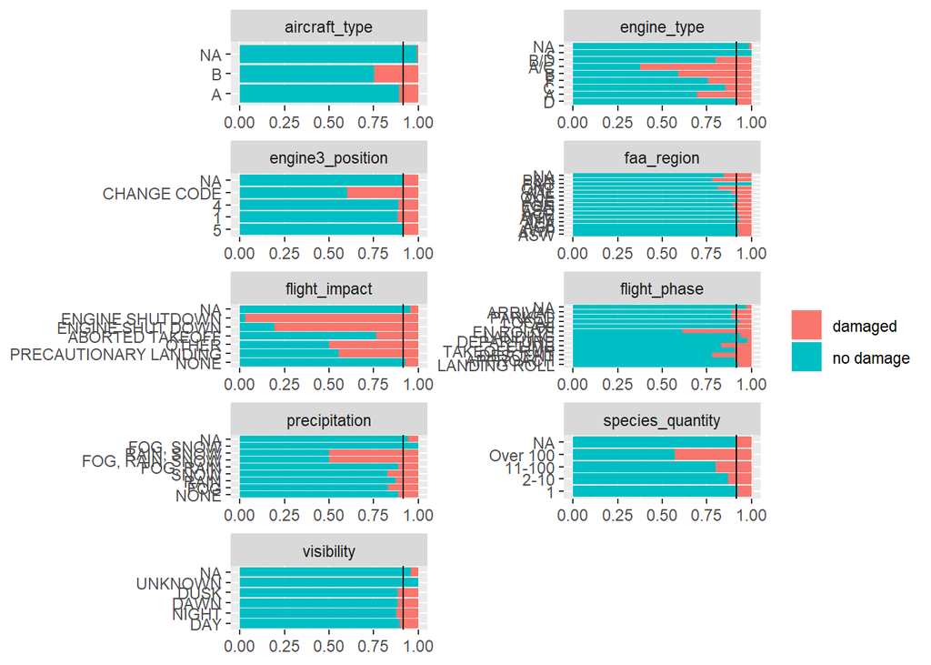

```r
train_orig%>%
  select(damaged,categoric_summary%>%
           filter(distinct<=15)%>%
           select(variable)%>%
           pull()
           )%>%
  pivot_longer(2:last_col())%>%
  ggplot(aes(y=value,fill=damaged))+
  geom_bar(position="fill")+
  geom_vline(xintercept = balance_share)+
  facet_wrap(vars(name),scales="free",ncol=2)+
  labs(
    x=NULL,y=NULL,fill=NULL
  )
```

> Closer inspection indeed indicates that some levels may provide better predictive capability. Dummy variables encoding may work wonders.

## Limited variables dataframe

Instead of lots of variables, I choose to use some select variables (taking cues from other bloggers and adding some of mine) for my model.

```r
train_df<-train_orig%>%
    select(
    damaged, flight_impact, precipitation,
    visibility, flight_phase, engines, incident_year,
    species_id, engine_type,aircraft_model,
    species_quantity, height, speed, distance
  )


train_df%>%
  glimpse()
```

```
## Rows: 21,000
## Columns: 14
## $ damaged          <fct> no damage, damaged, no damage, no damage, no damage, ~
## $ flight_impact    <fct> NA, NA, NONE, NONE, NA, NA, NA, NONE, NA, NA, NONE, N~
## $ precipitation    <fct> NA, NA, "NONE", "NONE", NA, NA, NA, "FOG", NA, NA, "N~
## $ visibility       <fct> DAY, NA, DAY, NIGHT, NIGHT, NA, NA, NIGHT, NA, NIGHT,~
## $ flight_phase     <fct> LANDING ROLL, NA, LANDING ROLL, APPROACH, APPROACH, N~
## $ engines          <dbl> 2, 2, 2, 2, NA, NA, 2, 1, NA, 2, 2, 2, 2, NA, 2, 2, 2~
## $ incident_year    <dbl> 1996, 1999, 2011, 2007, 2007, 2013, 2002, 2013, 2015,~
## $ species_id       <fct> UNKBM, UNKBM, ZT002, UNKBS, ZT105, YI005, UNKBM, UNKB~
## $ engine_type      <fct> D, D, D, D, NA, NA, D, A, NA, C, D, D, D, NA, D, D, D~
## $ aircraft_model   <dbl> NA, 26, 24, 42, NA, NA, 97, 7, NA, NA, 14, 22, 37, NA~
## $ species_quantity <fct> 1, 1, 1, 1, NA, 1, 1, 1, 1, 1, 1, 2-10, 1, 1, 2-10, 1~
## $ height           <dbl> 0, NA, 0, 300, NA, NA, NA, 2700, NA, 0, 3500, 1400, 0~
## $ speed            <dbl> 80, NA, NA, 130, 140, NA, NA, 110, NA, NA, 180, 170, ~
## $ distance         <dbl> 0, NA, 0, NA, NA, 0, NA, NA, 0, 0, NA, NA, 0, 0, 0, 0~
```

## Partitioning

Here I split the original training data into train and validation set. Then resample the train set with 10-fold stratified cross validation. Will use the validation set for another layer of checking of the model.

```r
set.seed(123)

splits<-initial_split(train_df,strata = damaged)


train<-training(splits)
valid<-testing(splits)

folds<-vfold_cv(train,v = 10,strata = damaged)
```

## Recipe to preprocess

Here the strategy is - * Handle factors with many levels by lumping them together * Removing highly correlated numeric variables * Dummy encoding * Imputation, zero variance feature removal * Wanted to upsample. But results were poor. So, keeping that option out

```r
rec_base<-train%>%
  recipe(damaged~.)%>%
  step_corr(all_numeric_predictors())%>%
  step_novel(all_nominal_predictors())%>%
  step_other(all_nominal_predictors(),threshold=0.01)%>%
  step_unknown(all_nominal_predictors())%>%
  step_dummy(all_nominal_predictors())%>%
  step_impute_median(all_numeric_predictors())%>%
  step_zv(all_predictors())

rec_base
```

```
## Data Recipe
##
## Inputs:
##
##       role #variables
##    outcome          1
##  predictor         13
##
## Operations:
##
## Correlation filter on all_numeric_predictors()
## Novel factor level assignment for all_nominal_predictors()
## Collapsing factor levels for all_nominal_predictors()
## Unknown factor level assignment for all_nominal_predictors()
## Dummy variables from all_nominal_predictors()
## Median Imputation for all_numeric_predictors()
## Zero variance filter on all_predictors()
```

## Model to use - GLMNet

We set two tunable parameters in GLMNet model.

```r
logistic_reg_glmnet_spec <-
  logistic_reg(penalty = tune(), mixture = tune()) %>%
  set_engine('glmnet')
```

## Create Workflow

```r
LR_glmnet_wf<-workflow()%>%
  add_recipe(rec_base)%>%
  add_model(logistic_reg_glmnet_spec)

LR_glmnet_wf
```

```
## == Workflow ====================================================================
## Preprocessor: Recipe
## Model: logistic_reg()
##
## -- Preprocessor ----------------------------------------------------------------
## 7 Recipe Steps
##
## * step_corr()
## * step_novel()
## * step_other()
## * step_unknown()
## * step_dummy()
## * step_impute_median()
## * step_zv()
##
## -- Model -----------------------------------------------------------------------
## Logistic Regression Model Specification (classification)
##
## Main Arguments:
##   penalty = tune()
##   mixture = tune()
##
## Computational engine: glmnet
```

## Tune grid for hyperparameter tuning

We vary with 20 different combination of penalty and mixture.

```r
LR_glmnet_grid<-grid_max_entropy(
  parameters(LR_glmnet_wf),
  size=20
)

LR_glmnet_grid%>%
    head()
```

```
## # A tibble: 6 x 2
##    penalty mixture
##      <dbl>   <dbl>
## 1 2.50e-10  0.0883
## 2 5.95e- 7  0.669
## 3 2.20e- 6  0.451
## 4 3.76e- 9  0.973
## 5 7.92e- 5  0.0864
## 6 2.28e- 4  0.777
```

## Tuning

```r
tic()

metrics_interest<-metric_set(mn_log_loss)

set.seed(123)

LR_glmnet_tune<-LR_glmnet_wf%>%
  tune_grid(
    resamples=folds,
    grid=LR_glmnet_grid,
    metrics=metrics_interest,
    control=control_grid(parallel_over =NULL)
  )

toc()
```

```
## 176.88 sec elapsed
```

```r
LR_glmnet_tune%>%
    collect_metrics()%>%
    slice_min(mean,n=5)
```

```
## # A tibble: 5 x 8
##    penalty mixture .metric     .estimator  mean     n std_err .config
##      <dbl>   <dbl> <chr>       <chr>      <dbl> <int>   <dbl> <chr>
## 1 4.59e- 4   0.978 mn_log_loss binary     0.216    10 0.00477 Preprocessor1_Mod~
## 2 8.38e- 4   0.404 mn_log_loss binary     0.216    10 0.00476 Preprocessor1_Mod~
## 3 2.28e- 4   0.777 mn_log_loss binary     0.216    10 0.00478 Preprocessor1_Mod~
## 4 1.09e-10   0.227 mn_log_loss binary     0.216    10 0.00479 Preprocessor1_Mod~
## 5 8.99e- 7   0.213 mn_log_loss binary     0.216    10 0.00478 Preprocessor1_Mod~
```

## Get the best parameters and fit on full training set

```r
best_params<-LR_glmnet_tune%>%select_best()
best_params
```

```
## # A tibble: 1 x 3
##    penalty mixture .config
##      <dbl>   <dbl> <chr>
## 1 0.000459   0.978 Preprocessor1_Model20
```

```r
final_wf_fit<-LR_glmnet_wf%>%
        finalize_workflow(best_params)%>%
        fit(data=train)
```

## Predict on validation sets

```r
valid_preds<-final_wf_fit%>%
    augment(valid)
```

```r
valid_preds%>%
    metrics_interest(truth=damaged,estimate=.pred_class,.pred_damaged)
```

```
## # A tibble: 1 x 3
##   .metric     .estimator .estimate
##   <chr>       <chr>          <dbl>
## 1 mn_log_loss binary         0.221
```

Validation metrics are pretty close to our resampling metrics. So, we may not be overfitting.

## Predict on test set and submission file

```r
test_preds<-final_wf_fit%>%
    augment(test)%>%
    select(id,damaged=.pred_damaged)

test_preds%>%head()
```

```
## # A tibble: 6 x 2
##      id damaged
##   <dbl>   <dbl>
## 1 11254 0.0902
## 2 27716 0.0149
## 3 29066 0.0218
## 4  3373 0.0724
## 5  1996 0.0684
## 6 18061 0.00466
```

```r
stopCluster(core_cluster)
```

## Conclusion

This yielded a score of 0.219 in private leaderboard and 0.165 in public leaderboard. You can find details submission stats on my [Kaggle submission notebook](https://www.kaggle.com/mobijoker/tidymodels-with-glmnet-on-sliced-s01e02-data).